# Time Varying Regression Lab 1

# Load the data

```r
load("landings.RData")
landings$log.metric.tons = log(landings$metric.tons)
landings = subset(landings, Year <= 1987)
```

# Look at the data

```r
head(landings)
```

| Year | Species | metric.tons | log.metric.tons |
| --- | --- | --- | --- |
| 1964 | Anchovy | 5.45e+03 | 8.6 |
| 1965 | Anchovy | 4.26e+03 | 8.36 |
| 1966 | Anchovy | 5.15e+03 | 8.55 |
| 1967 | Anchovy | 7.27e+03 | 8.89 |
| 1968 | Anchovy | 6.35e+03 | 8.76 |
| 1969 | Anchovy | 7.04e+03 | 8.86 |

```r
unique(landings$Species)
```

```
## [1] Anchovy        Sardine        Chub.mackerel  Horse.mackerel
## [5] Mackerel       Jack.Mackerel
## 6 Levels: Anchovy Sardine Chub.mackerel Horse.mackerel ... Jack.Mackerel
```

# Subset the data

```r
val <- "Sardine"
dat <- subset(landings, Species==val)
```

# Class of the data

```r
class(dat)
```

```
## [1] "data.frame"
```

Because it is a data.frame, you can call the columns like so

```r
dat$log.metric.tons
```

```
##  [1] 9.471504 9.269656 9.344679 9.103534 9.118203 9.270052 9.085083
##  [8] 9.119573 9.371089 9.491134 9.298525 9.432539 9.447339 9.404961
## [15] 9.383293 9.450538 9.397840 9.429829 9.423539 9.233666 9.245341
## [22] 9.349267 9.246258 9.178334
```

# Plot data with ggplot

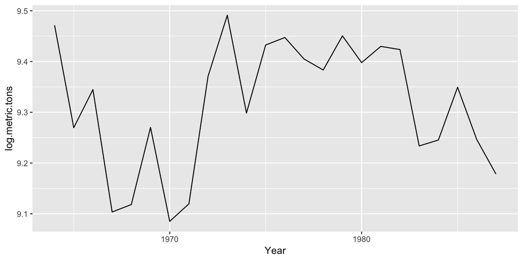

```r
library(ggplot2)
ggplot(dat, aes(x=Year, y=log.metric.tons)) +
  geom_line()
```

# Plot data with base plot

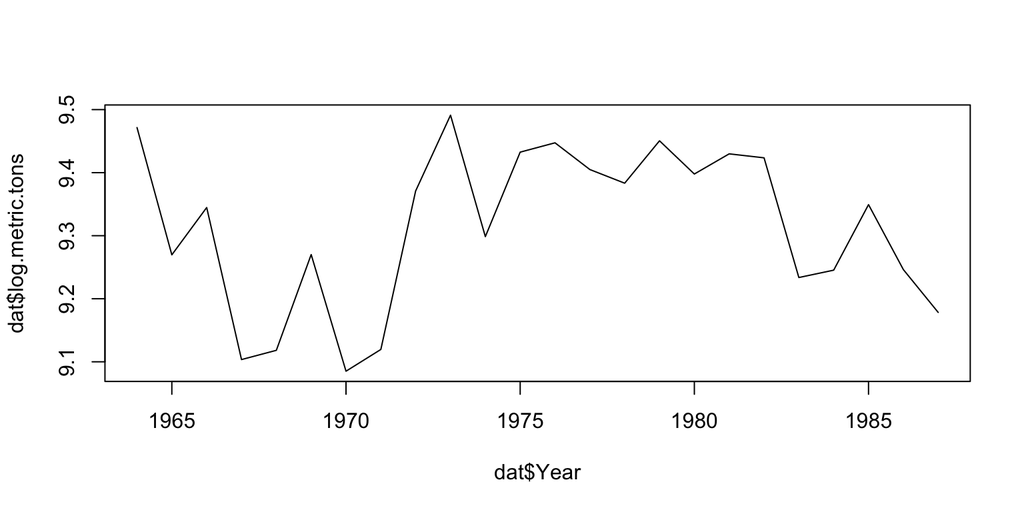

```r
plot(dat$Year, dat$log.metric.tons, type="l")
```

# Fit a 3th-order linear regression against year

First add $t$, $t^2$ and $t^3$ to the landings. $t$ is Year minus first Year. So first year is 0.

```r
landings$t <- landings$Year-landings$Year[1]
landings$t2 <- (landings$t)^2
landings$t3 <- (landings$t)^3
dat <- subset(landings, Species==val)
head(dat)
```

| Year | Species | metric.tons | log.metric.tons | t | t2 | t3 |
| --- | --- | --- | --- | --- | --- | --- |
| 1964 | Sardine | 1.3e+04 | 9.47 | 0 | 0 | 0 |
| 1965 | Sardine | 1.06e+04 | 9.27 | 1 | 1 | 1 |
| 1966 | Sardine | 1.14e+04 | 9.34 | 2 | 4 | 8 |
| 1967 | Sardine | 8.99e+03 | 9.1 | 3 | 9 | 27 |
| 1968 | Sardine | 9.12e+03 | 9.12 | 4 | 16 | 64 |
| 1969 | Sardine | 1.06e+04 | 9.27 | 5 | 25 | 125 |

# Fit the regression

We are fitting this model

$$log(Sardine catch) = \alpha + \beta t + \beta_2 t^2 + \beta_3 t^3 + e_t$$

```r
model <- lm(log.metric.tons ~ t + t2 + t3, data=dat)
```

Look at the model.

```r
summary(model)
```

```
##
## Call:
## lm(formula = log.metric.tons ~ t + t2 + t3, data = dat)
##
## Residuals:
##       Min        1Q    Median        3Q       Max
## -0.155240 -0.052781  0.008525  0.063977  0.200622
##
## Coefficients:
##               Estimate Std. Error t value Pr(>|t|)
## (Intercept)  9.361e+00  7.045e-02 132.860  < 2e-16 ***
## t           -6.414e-02  2.710e-02  -2.366  0.02816 *
## t2           8.790e-03  2.773e-03   3.170  0.00481 **
## t3          -2.808e-04  7.917e-05  -3.547  0.00202 **
## ---
## Signif. codes:  0 '***' 0.001 '**' 0.01 '*' 0.05 '.' 0.1 ' ' 1
##
## Residual standard error: 0.1001 on 20 degrees of freedom
## Multiple R-squared:  0.4566, Adjusted R-squared:  0.375
## F-statistic: 5.601 on 3 and 20 DF,  p-value: 0.005907
```

# Fit using the I() function

You don’t need to add $t^2$ and $t^3$ etc to your data frame. You can use the `I()` function.

```r
model2 <- lm(log.metric.tons ~ t + I(t^2) + I(t^3) + I(t^4), data=dat)
```

```r
summary(model2)
```

```
##
## Call:
## lm(formula = log.metric.tons ~ t + I(t^2) + I(t^3) + I(t^4),
##     data = dat)
##
## Residuals:
##       Min        1Q    Median        3Q       Max
## -0.115300 -0.053090 -0.008895  0.041783  0.165885
##
## Coefficients:
##               Estimate Std. Error t value Pr(>|t|)
## (Intercept)  9.464e+00  6.822e-02 138.726  < 2e-16 ***
## t           -1.754e-01  4.298e-02  -4.080 0.000638 ***
## I(t^2)       3.164e-02  7.842e-03   4.035 0.000707 ***
## I(t^3)      -1.847e-03  5.176e-04  -3.569 0.002047 **
## I(t^4)       3.406e-05  1.116e-05   3.052 0.006562 **
## ---
## Signif. codes:  0 '***' 0.001 '**' 0.01 '*' 0.05 '.' 0.1 ' ' 1
##
## Residual standard error: 0.08412 on 19 degrees of freedom
## Multiple R-squared:  0.6353, Adjusted R-squared:  0.5586
## F-statistic: 8.275 on 4 and 19 DF,  p-value: 0.0004846
```

# Fit using the poly function

The proper way to fit a time-varying regression with a polynomial $t$ is to use `poly()`, but Stergiou and Christou fit a raw polynomial regression. I repeat Stergiou and Christou’s approach but keep in mind that you should use `poly()` for a real analysis.

```r
model3 <- lm(log.metric.tons ~ poly(t,3), data=dat)
```

```r
summary(model3)
```

```
##
## Call:
## lm(formula = log.metric.tons ~ poly(t, 3), data = dat)
##
## Residuals:
##       Min        1Q    Median        3Q       Max
## -0.155240 -0.052781  0.008525  0.063977  0.200622
##
## Coefficients:
##             Estimate Std. Error t value Pr(>|t|)
## (Intercept)  9.31524    0.02043 455.923  < 2e-16 ***
## poly(t, 3)1  0.08314    0.10009   0.831  0.41602
## poly(t, 3)2 -0.18809    0.10009  -1.879  0.07488 .
## poly(t, 3)3 -0.35504    0.10009  -3.547  0.00202 **
## ---
## Signif. codes:  0 '***' 0.001 '**' 0.01 '*' 0.05 '.' 0.1 ' ' 1
##
## Residual standard error: 0.1001 on 20 degrees of freedom
## Multiple R-squared:  0.4566, Adjusted R-squared:  0.375
## F-statistic: 5.601 on 3 and 20 DF,  p-value: 0.005907
```

# Show the coefficients

```r
coef(model)
```

```
##   (Intercept)             t            t2            t3
##  9.3605023339 -0.0641416599  0.0087901653 -0.0002808215
```

# Show the fitted values

This is the model predicted values.

```r
fitted(model)
```

```
##       45       46       47       48       49       50       51       52
## 9.360502 9.304870 9.265133 9.239607 9.226606 9.224445 9.231441 9.245907
##       53       54       55       56       57       58       59       60
## 9.266159 9.290512 9.317281 9.344781 9.371327 9.395234 9.414817 9.428392
##       61       62       63       64       65       66       67       68
## 9.434273 9.430776 9.416215 9.388906 9.347163 9.289303 9.213639 9.118487
```

# Plot model fit over the data

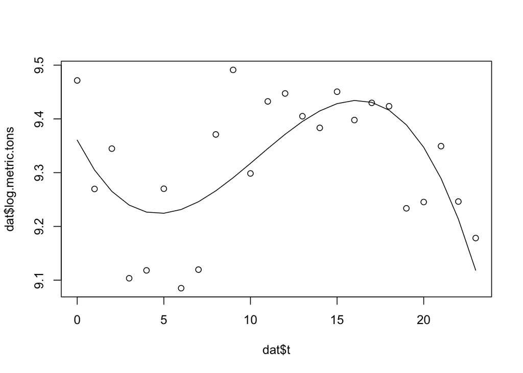

```r
plot(dat$t, dat$log.metric.tons)
lines(dat$t, fitted(model))
```

or with ggplot

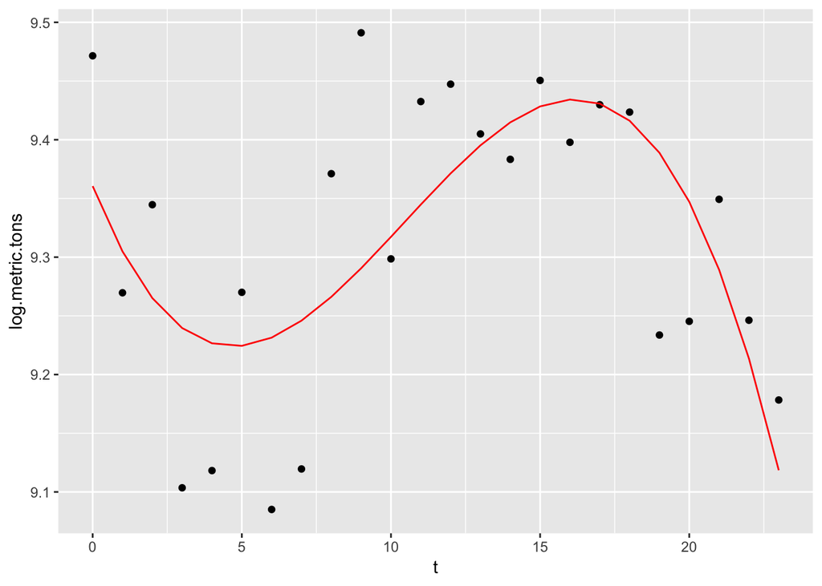

```r
fitted.df <- data.frame(t = dat$t, fitted=fitted(model))
ggplot(dat, aes(x=t, y=log.metric.tons)) +
  geom_point() +
  geom_line(color='red',data = fitted.df, aes(x=t, y=fitted))
```

# Show the residuals

This is the difference between the data and the fitted line.

```r
residuals(model)
```

```
##            45            46            47            48            49
##  0.1110015820 -0.0352141158  0.0795458353 -0.1360722943 -0.1084026116
##            50            51            52            53            54
##  0.0456061531 -0.1463576622 -0.1263341902  0.1049301962  0.2006218414
##            55            56            57            58            59
## -0.0187555657  0.0877587806  0.0760127752  0.0097270668 -0.0315241974
##            60            61            62            63            64
##  0.0221455159 -0.0364331808 -0.0009467464  0.0073234387 -0.1552398025
##            65            66            67            68
## -0.1018228357  0.0599644510  0.0326187567  0.0598468097
```

# Test the residuals for independence

For the Ljung-Box test, we need to know how many parameters were estimated. We can see this by looking at the estimated coefficients.

```r
coef(model)
```

```
##   (Intercept)             t            t2            t3
##  9.3605023339 -0.0641416599  0.0087901653 -0.0002808215
```

```r
np <- length(coef(model))
```

Stergiou and Christou use lag=14, which is a bit large, but we will use that to copy them.

```r
x <- resid(model)
Box.test(x, lag = 14, type = "Ljung-Box", fitdf=np)
```

```
##
##  Box-Ljung test
##
## data:  x
## X-squared = 15.127, df = 10, p-value = 0.1275
```

We can also use the [Breusch-Godfrey](https://en.wikipedia.org/wiki/Breusch%E2%80%93Godfrey_test) test, which is more standard for regression models. The null hypothesis is that the data are temporally independent. So we do not want to reject the null.

The `checkresiduals()` function in the forecast package shows diagnostic plots and also the Breusch-Godfrey test results.

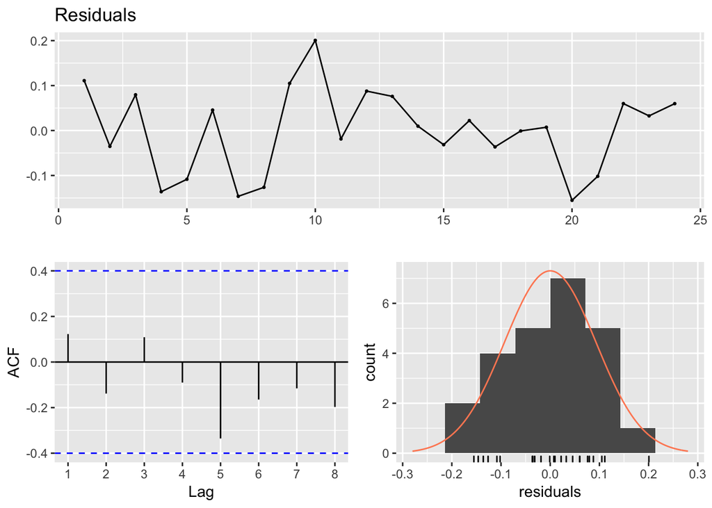

```
##
##  Breusch-Godfrey test for serial correlation of order up to 7
##
## data:  Residuals
## LM test = 6.7563, df = 7, p-value = 0.4547
```

```r
library(forecast)
checkresiduals(model)
```

If the p-value is less than 0.05, it indicates support for temporally autocorrelated residuals, which means that your assumption of uncorrelated residuals is not supported. You can also look at the ACF function.

# Problems

1. Fit a 1st order polynomial to the sardine data. This is $C_t = \alpha + \beta t + e_t$. Plot the data and then the fit on top of the data.

```r
lm1 <- lm(log.metric.tons ~ t, data=dat)
```

1. Fit a 2nd order polynomial to the sardine data. This is $C_t = \alpha + \beta t + \beta_2 t^2 + e_t$. Plot the data and then the fit on top of the data.

```r
lm1 <- lm(log.metric.tons ~ t + I(t^2), data=dat)
```

1. Try fitting a 4th order time-varying regression for one of the other species.

```r
unique(landings$Species)
```

```
## [1] Anchovy        Sardine        Chub.mackerel  Horse.mackerel
## [5] Mackerel       Jack.Mackerel
## 6 Levels: Anchovy Sardine Chub.mackerel Horse.mackerel ... Jack.Mackerel
```

1. Fit a 4th order polynomial.
2. Do a `summary(model)` and evaluate what level of polynomial is supported.
3. Plot the data with the fit on top.